# NFL 2020 Week 13

MAJ Daniel Baller

8/27/2019

## Instructor Group Predictions

This Week's Predictions

Week 13

| Game | Prediction | Winner | Correct | Correct Votes | Correct Percent |
| --- | --- | --- | --- | --- | --- |
| 1 | Chicago Bears | Detroit Lions | No | 3 | 0.1765 |
| 2 | Tennessee Titans | Cleveland Browns | No | 3 | 0.1765 |
| 3 | Indianapolis Colts | Indianapolis Colts | Yes | 16 | 0.9412 |
| 4 | Minnesota Vikings | Minnesota Vikings | Yes | 17 | 1.0000 |
| 5 | New Orleans Saints | New Orleans Saints | Yes | 15 | 0.8824 |
| 6 | Las Vegas Raiders | Las Vegas Raiders | Yes | 16 | 0.9412 |
| 7 | Miami Dolphins | Miami Dolphins | Yes | 16 | 0.9412 |
| 8 | Seattle Seahawks | New York Giants | No | 0 | 0.0000 |
| 9 | Los Angeles Rams | Los Angeles Rams | Yes | 10 | 0.5882 |
| 10 | Green Bay Packers | Green Bay Packers | Yes | 17 | 1.0000 |
| 11 | New England Patriots | New England Patriots | Yes | 15 | 0.8824 |
| 12 | Kansas City Chiefs | Kansas City Chiefs | Yes | 17 | 1.0000 |
| 13 | Pittsburgh Steelers | Washington Football Team | No | 0 | 0.0000 |
| 14 | Buffalo Bills | Buffalo Bills | Yes | 15 | 0.8824 |
| 15 | Baltimore Ravens | Baltimore Ravens | Yes | 17 | 1.0000 |

Our win percentage for the week is 0.7333

Our season win percentage so far is 0.6474

Games picked this season 190

Correct Games this season 123

predictions this week

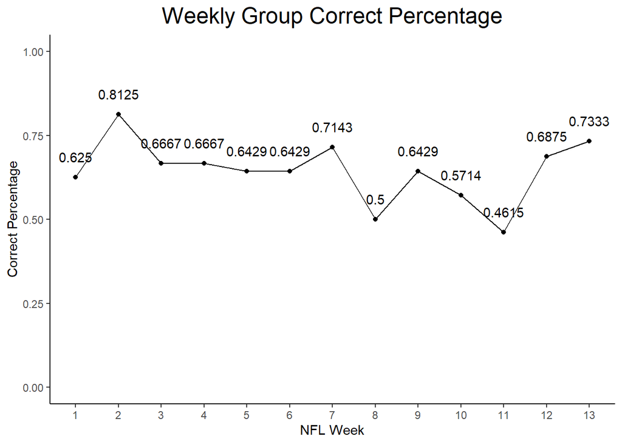

## Individual Predictions

Individual Results

Week 13

Name

Weekly # Correct

Percent

Weeks Picked

Season Percent

Adj Season Percent

Season Trend

Week 1

Week 2

Week 3

Week 4

Week 5

Week 6

Week 7

Week 8

Week 9

Week 10

Week 11

Week 12

Week 13

James Pleuss

9

12

10

12

7

8

10

9

9

10

7

10

12

0.8000

13

0.6579

0.6579

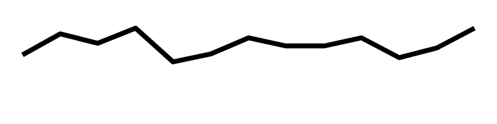

Josephine Cammack

9

11

12

10

9

9

11

7

6

8

NA

9

12

0.8000

12

0.6384

0.5893

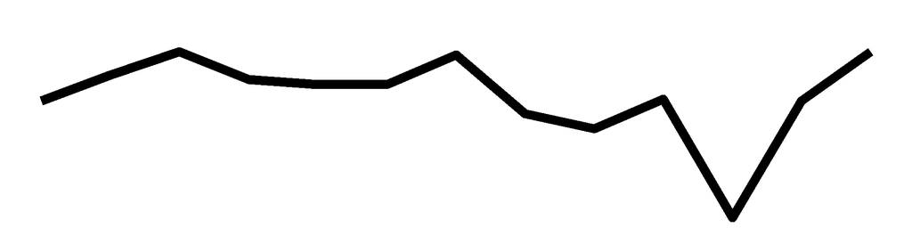

James Starling

15

12

9

12

10

NA

11

8

10

10

6

11

11

0.7333

12

0.7102

0.6556

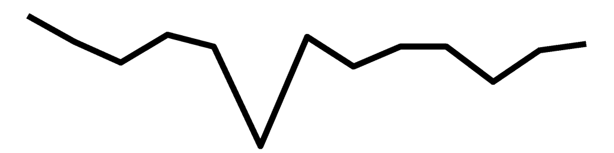

Daniel Baller

11

10

10

9

9

5

8

9

11

10

8

11

11

0.7333

13

0.6421

0.6421

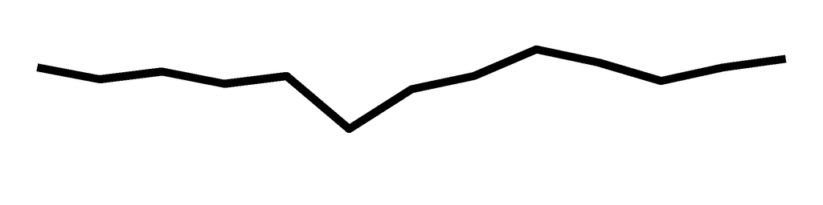

Michael Prokos

9

12

9

8

11

10

9

7

9

9

7

10

11

0.7333

13

0.6368

0.6368

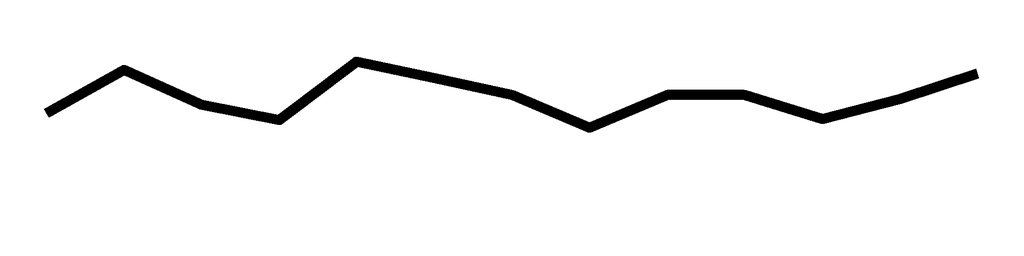

Margaret Wieczorek

11

14

9

9

8

NA

10

8

9

8

7

8

11

0.7333

12

0.6364

0.5874

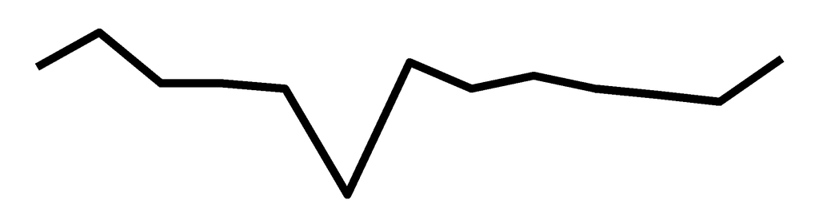

Gabriel Costa

9

12

6

9

10

7

9

7

10

10

9

NA

11

0.7333

12

0.6264

0.5782

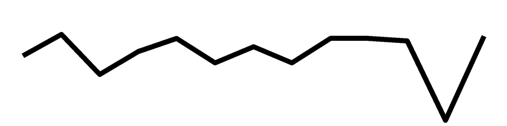

John Kearby

9

11

6

9

9

8

12

6

9

10

6

10

11

0.7333

13

0.6105

0.6105

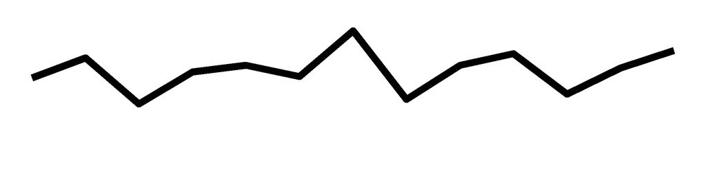

Blake Schwartz

10

9

10

10

10

9

9

6

5

8

7

9

11

0.7333

13

0.5947

0.5947

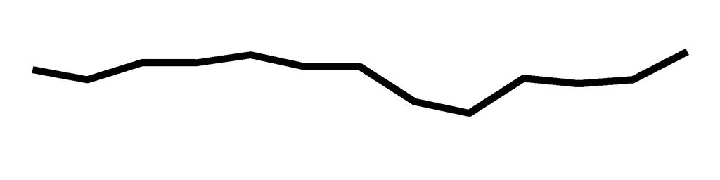

Eric Swenson

4

8

10

9

9

8

9

8

7

8

8

10

11

0.7333

13

0.5737

0.5737

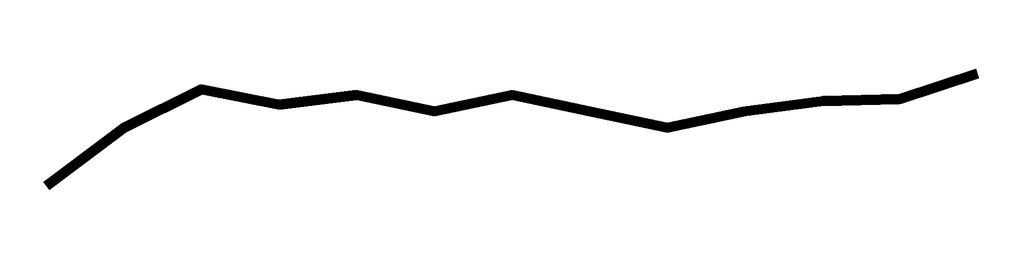

Shane Clark

10

14

9

9

9

9

10

NA

11

7

7

12

10

0.6667

12

0.6648

0.6137

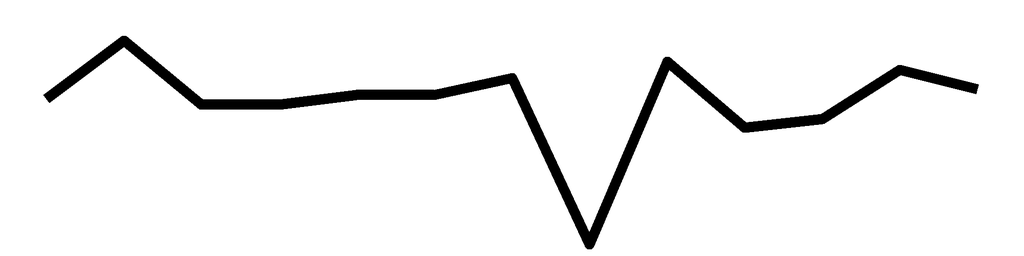

Kevin Cummiskey

13

11

9

9

10

7

9

5

10

9

7

12

10

0.6667

13

0.6368

0.6368

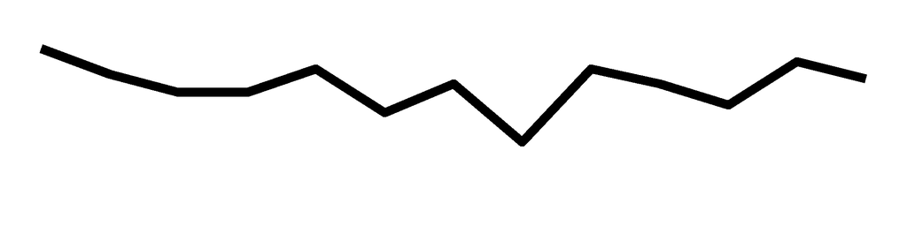

Gregory Minetos

9

14

10

12

8

8

12

7

10

7

7

11

9

0.6000

13

0.6526

0.6526

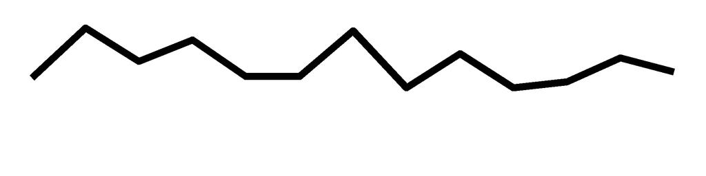

Nicholas Reisweber

9

10

10

8

10

7

8

8

10

9

6

14

9

0.6000

13

0.6211

0.6211

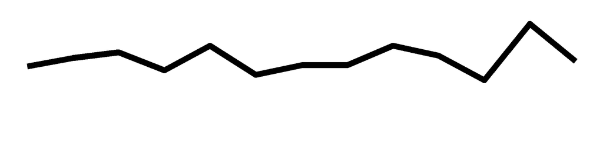

Frank Czerniakowski

7

13

10

9

8

6

9

6

11

5

9

11

9

0.6000

13

0.5947

0.5947

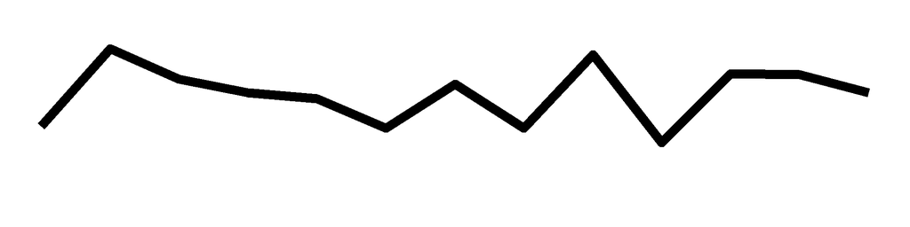

Timothy Moore

10

11

8

9

7

9

7

7

7

NA

NA

NA

9

0.6000

10

0.5714

0.4395

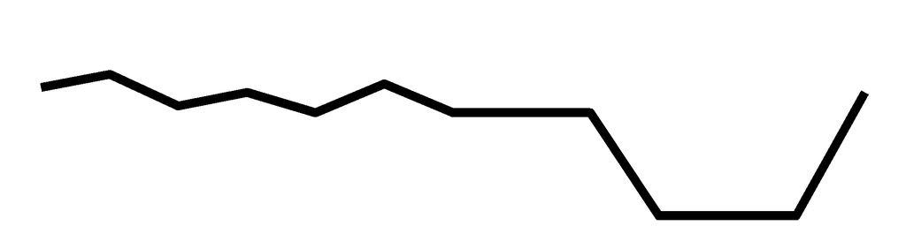

Tina Hartley

9

11

10

8

8

9

9

7

3

8

6

10

9

0.6000

13

0.5632

0.5632

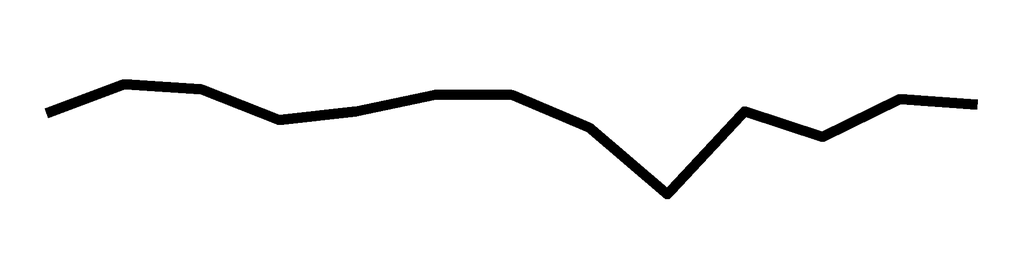

Daniel Richardson

13

11

10

10

8

NA

8

NA

NA

NA

NA

NA

NA

0.0000

6

0.6667

0.3077

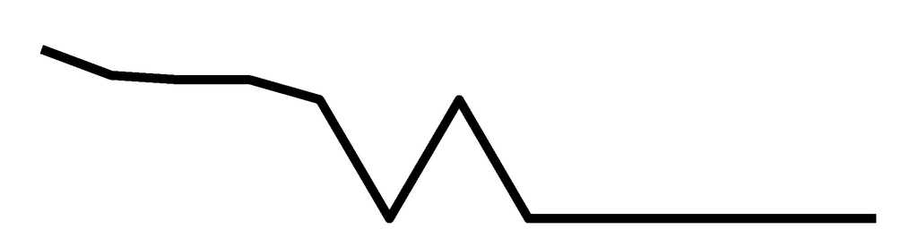

Travis Russell

11

8

8

11

10

10

10

8

NA

NA

7

NA

NA

0.0000

9

0.6336

0.4386

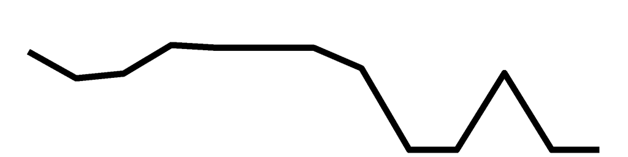

Welvin Lucero

9

11

9

10

NA

NA

11

8

NA

8

5

NA

NA

0.0000

8

0.6068

0.3734

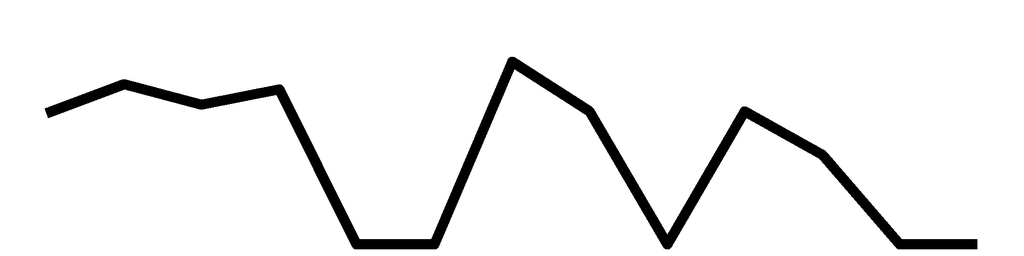

Kevin Quigley

8

8

9

10

10

8

8

6

8

7

9

10

NA

0.0000

12

0.5771

0.5327

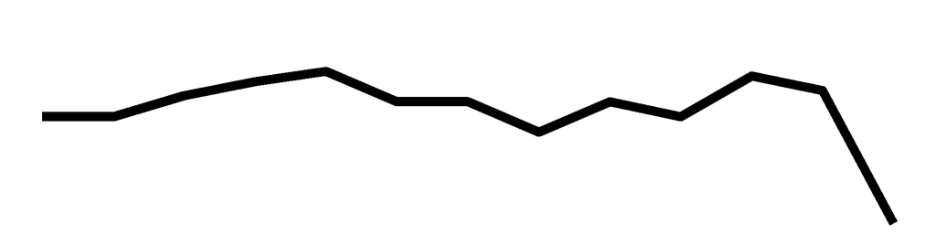

Andrew Lee

9

10

8

NA

NA

NA

NA

NA

NA

NA

NA

NA

NA

0.0000

3

0.5745

0.1326

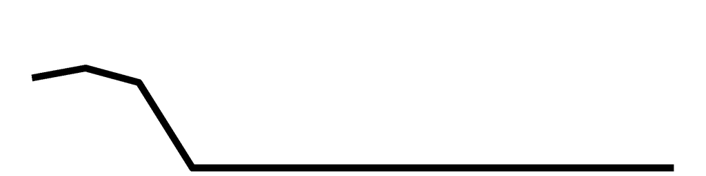

Congrats James Pleuss for having the best picks this week, with a correct percentage of 0.8, Congrats Josephine Cammack for having the best picks this week, with a correct percentage of 0.8

| Name | Week 1 | Week 2 | Week 3 | Week 4 | Week 5 | Week 6 | Week 7 | Week 8 | Week 9 | Week 10 | Week 11 | Week 12 | Week 13 | Percent | Weeks Picked | Season Percent | Adj Season Percent | Season Trend |
| --- | --- | --- | --- | --- | --- | --- | --- | --- | --- | --- | --- | --- | --- | --- | --- | --- | --- | --- |
| James Pleuss | 9 | 12 | 10 | 12 | 7 | 8 | 10 | 9 | 9 | 10 | 7 | 10 | 12 | 0.8000 | 13 | 0.6579 | 0.6579 |  |
| Josephine Cammack | 9 | 11 | 12 | 10 | 9 | 9 | 11 | 7 | 6 | 8 | NA | 9 | 12 | 0.8000 | 12 | 0.6384 | 0.5893 |  |
| James Starling | 15 | 12 | 9 | 12 | 10 | NA | 11 | 8 | 10 | 10 | 6 | 11 | 11 | 0.7333 | 12 | 0.7102 | 0.6556 |  |
| Daniel Baller | 11 | 10 | 10 | 9 | 9 | 5 | 8 | 9 | 11 | 10 | 8 | 11 | 11 | 0.7333 | 13 | 0.6421 | 0.6421 |  |
| Michael Prokos | 9 | 12 | 9 | 8 | 11 | 10 | 9 | 7 | 9 | 9 | 7 | 10 | 11 | 0.7333 | 13 | 0.6368 | 0.6368 |  |
| Margaret Wieczorek | 11 | 14 | 9 | 9 | 8 | NA | 10 | 8 | 9 | 8 | 7 | 8 | 11 | 0.7333 | 12 | 0.6364 | 0.5874 |  |
| Gabriel Costa | 9 | 12 | 6 | 9 | 10 | 7 | 9 | 7 | 10 | 10 | 9 | NA | 11 | 0.7333 | 12 | 0.6264 | 0.5782 |  |
| John Kearby | 9 | 11 | 6 | 9 | 9 | 8 | 12 | 6 | 9 | 10 | 6 | 10 | 11 | 0.7333 | 13 | 0.6105 | 0.6105 |  |
| Blake Schwartz | 10 | 9 | 10 | 10 | 10 | 9 | 9 | 6 | 5 | 8 | 7 | 9 | 11 | 0.7333 | 13 | 0.5947 | 0.5947 |  |
| Eric Swenson | 4 | 8 | 10 | 9 | 9 | 8 | 9 | 8 | 7 | 8 | 8 | 10 | 11 | 0.7333 | 13 | 0.5737 | 0.5737 |  |
| Shane Clark | 10 | 14 | 9 | 9 | 9 | 9 | 10 | NA | 11 | 7 | 7 | 12 | 10 | 0.6667 | 12 | 0.6648 | 0.6137 |  |
| Kevin Cummiskey | 13 | 11 | 9 | 9 | 10 | 7 | 9 | 5 | 10 | 9 | 7 | 12 | 10 | 0.6667 | 13 | 0.6368 | 0.6368 |  |
| Gregory Minetos | 9 | 14 | 10 | 12 | 8 | 8 | 12 | 7 | 10 | 7 | 7 | 11 | 9 | 0.6000 | 13 | 0.6526 | 0.6526 |  |
| Nicholas Reisweber | 9 | 10 | 10 | 8 | 10 | 7 | 8 | 8 | 10 | 9 | 6 | 14 | 9 | 0.6000 | 13 | 0.6211 | 0.6211 |  |
| Frank Czerniakowski | 7 | 13 | 10 | 9 | 8 | 6 | 9 | 6 | 11 | 5 | 9 | 11 | 9 | 0.6000 | 13 | 0.5947 | 0.5947 |  |
| Timothy Moore | 10 | 11 | 8 | 9 | 7 | 9 | 7 | 7 | 7 | NA | NA | NA | 9 | 0.6000 | 10 | 0.5714 | 0.4395 |  |
| Tina Hartley | 9 | 11 | 10 | 8 | 8 | 9 | 9 | 7 | 3 | 8 | 6 | 10 | 9 | 0.6000 | 13 | 0.5632 | 0.5632 |  |
| Daniel Richardson | 13 | 11 | 10 | 10 | 8 | NA | 8 | NA | NA | NA | NA | NA | NA | 0.0000 | 6 | 0.6667 | 0.3077 |  |
| Travis Russell | 11 | 8 | 8 | 11 | 10 | 10 | 10 | 8 | NA | NA | 7 | NA | NA | 0.0000 | 9 | 0.6336 | 0.4386 |  |
| Welvin Lucero | 9 | 11 | 9 | 10 | NA | NA | 11 | 8 | NA | 8 | 5 | NA | NA | 0.0000 | 8 | 0.6068 | 0.3734 |  |
| Kevin Quigley | 8 | 8 | 9 | 10 | 10 | 8 | 8 | 6 | 8 | 7 | 9 | 10 | NA | 0.0000 | 12 | 0.5771 | 0.5327 |  |
| Andrew Lee | 9 | 10 | 8 | NA | NA | NA | NA | NA | NA | NA | NA | NA | NA | 0.0000 | 3 | 0.5745 | 0.1326 |  |

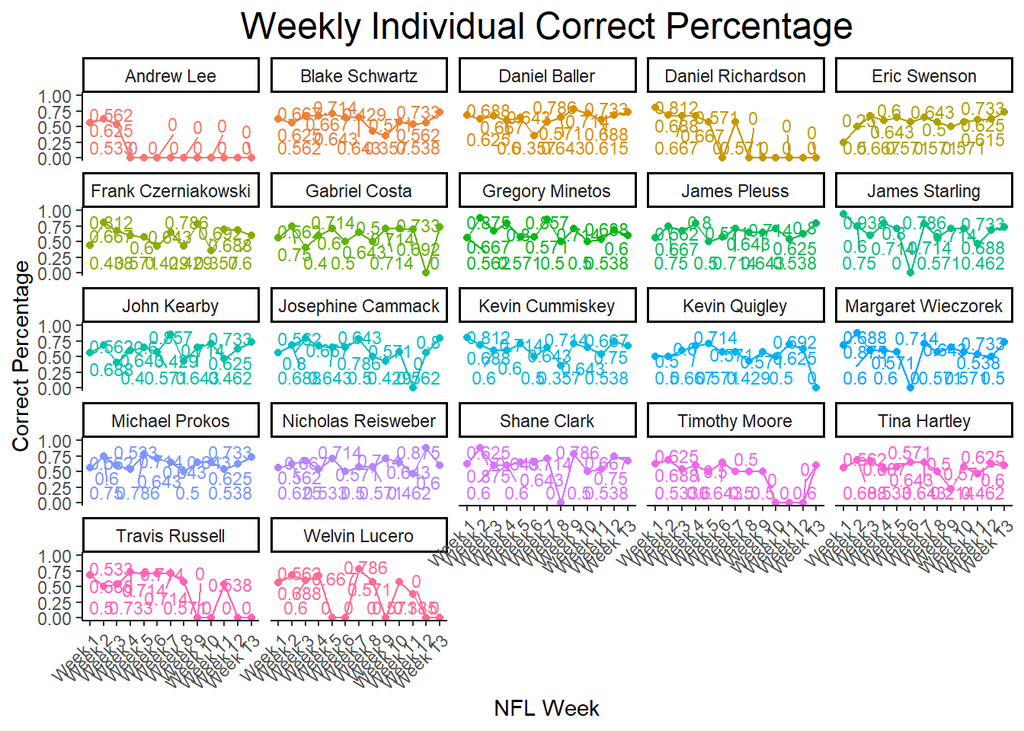

## MA206 Group Predictions

This Week's MA206 Predictions

Week 13

| Game | Prediction | Winner | Correct | Correct Votes | Correct Percent |
| --- | --- | --- | --- | --- | --- |
| 1 | Chicago Bears | Detroit Lions | No | 3 | 0.2143 |
| 2 | Tennessee Titans | Cleveland Browns | No | 5 | 0.3571 |
| 3 | Indianapolis Colts | Indianapolis Colts | Yes | 13 | 0.9286 |
| 4 | Minnesota Vikings | Minnesota Vikings | Yes | 14 | 1.0000 |
| 5 | New Orleans Saints | New Orleans Saints | Yes | 12 | 0.8571 |
| 6 | Las Vegas Raiders | Las Vegas Raiders | Yes | 14 | 1.0000 |
| 7 | Miami Dolphins | Miami Dolphins | Yes | 14 | 1.0000 |
| 8 | Seattle Seahawks | New York Giants | No | 0 | 0.0000 |
| 9 | Arizona Cardinals | Los Angeles Rams | No | 5 | 0.3571 |
| 10 | Green Bay Packers | Green Bay Packers | Yes | 11 | 0.7857 |
| 11 | New England Patriots | New England Patriots | Yes | 10 | 0.7143 |
| 12 | Kansas City Chiefs | Kansas City Chiefs | Yes | 14 | 1.0000 |
| 13 | Pittsburgh Steelers | Washington Football Team | No | 0 | 0.0000 |
| 14 | Buffalo Bills | Buffalo Bills | Yes | 13 | 0.9286 |
| 15 | Baltimore Ravens | Baltimore Ravens | Yes | 13 | 0.9286 |

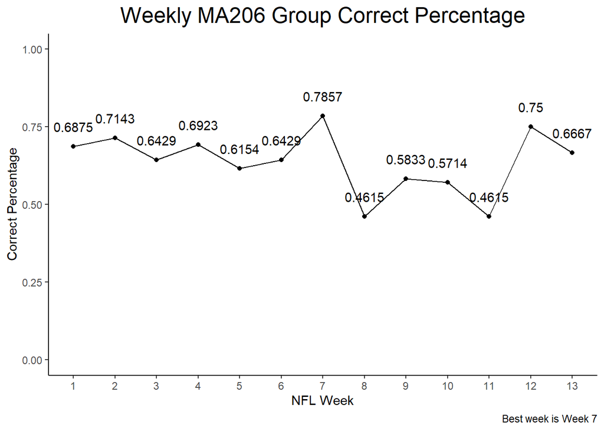

# Cadet Individual Results

MA206 Individual Results

Week 13

Name

Weekly # Correct

Percent

Weeks Picked

Season Percent

Adj Season Percent

Season Trend

Week 1

Week 2

Week 3

Week 4

Week 5

Week 6

Week 7

Week 8

Week 9

Week 10

Week 11

Week 12

Week 13

Caroline Swenson

8

12

11

13

7

8

10

NA

8

9

8

NA

12

0.8000

11

0.6625

0.5606

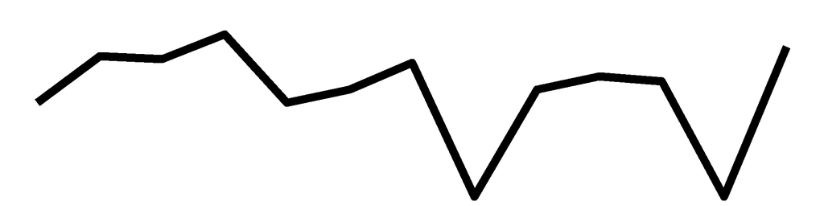

Gabriela Peralta

11

8

9

NA

8

8

10

6

NA

8

6

10

12

0.8000

11

0.5963

0.5046

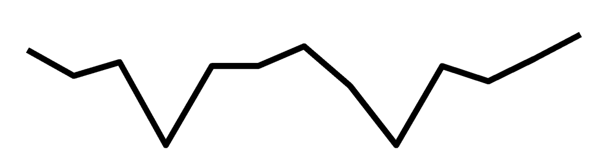

Ryan Jackovic

11

10

NA

7

7

8

8

7

NA

4

5

NA

12

0.8000

10

0.5448

0.4191

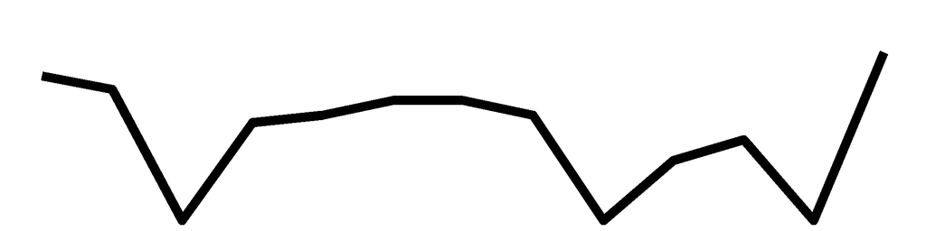

Paige Lennon

NA

NA

NA

11

10

8

11

8

6

8

6

9

11

0.7333

10

0.6154

0.4734

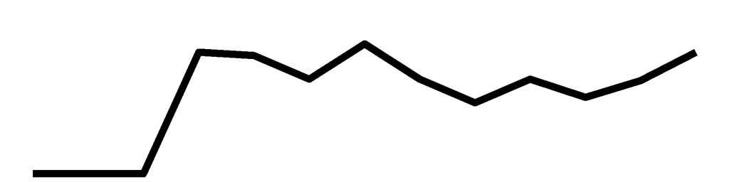

Sydney Shannon

10

9

8

9

8

7

9

5

8

10

8

10

11

0.7333

13

0.5895

0.5895

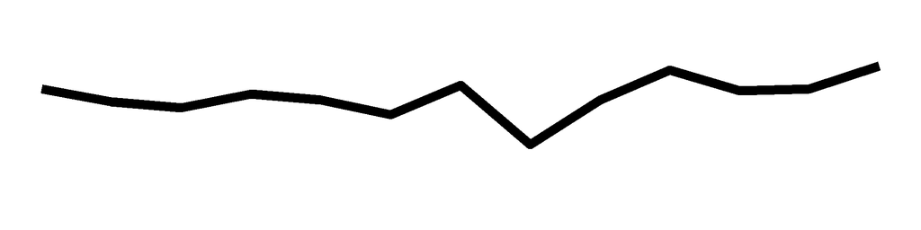

Laurence Dowd

10

10

10

9

10

NA

12

NA

10

8

7

NA

10

0.6667

10

0.6575

0.5058

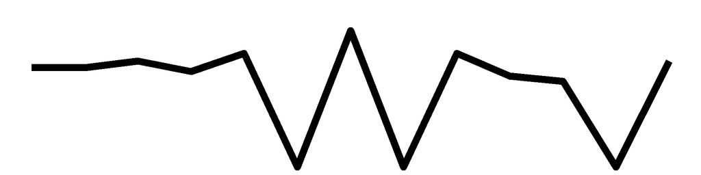

Victor Olawale-Apanpa

8

NA

10

NA

10

NA

10

7

7

9

6

11

10

0.6667

10

0.6069

0.4668

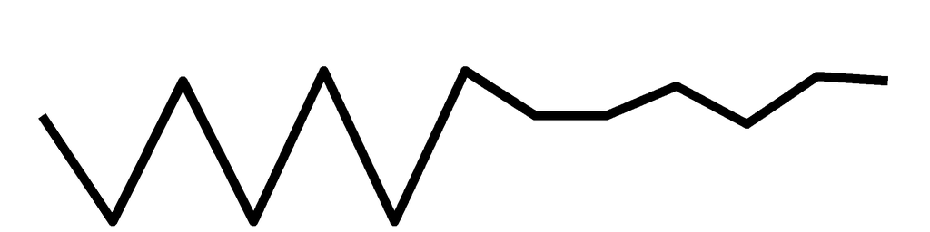

Sidney Cash

10

10

NA

10

NA

8

8

7

11

8

5

10

10

0.6667

11

0.6025

0.5098

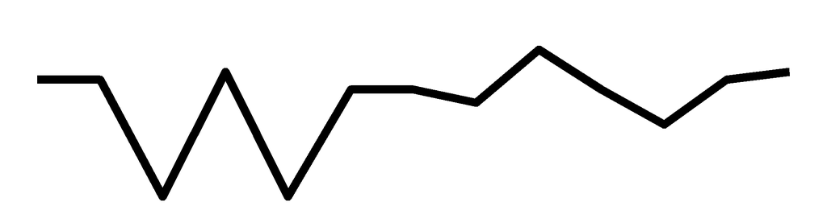

Joshua Gilliard

9

8

9

10

10

7

10

7

5

8

NA

10

10

0.6667

12

0.5819

0.5371

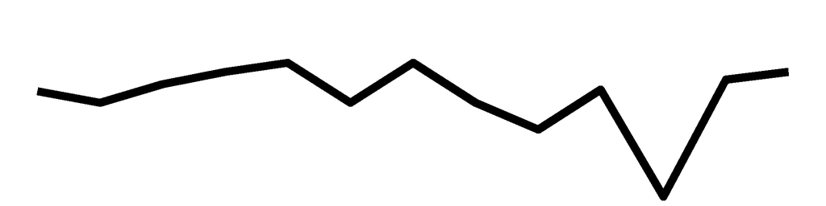

Thomas Bizub

10

14

8

11

8

9

10

8

10

12

9

11

9

0.6000

13

0.6789

0.6789

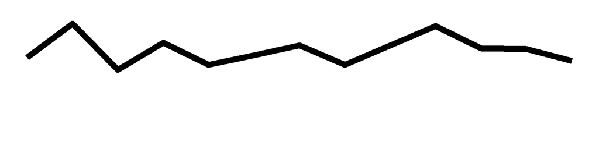

Christopher Erb

9

9

7

11

9

11

8

11

10

9

5

10

9

0.6000

13

0.6211

0.6211

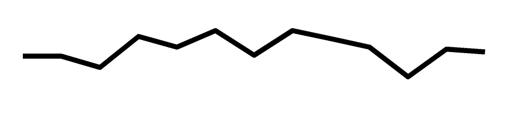

Joshua Loyd

11

9

8

NA

6

9

NA

6

10

8

NA

10

9

0.6000

10

0.5811

0.4470

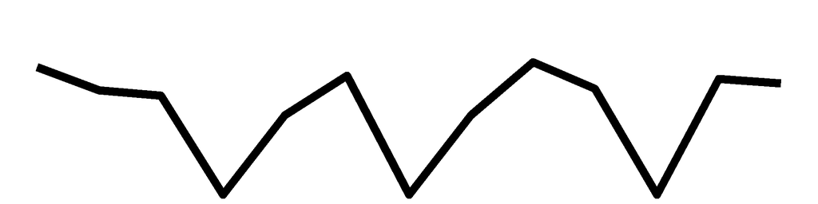

John White

10

11

10

8

12

9

11

6

9

9

8

10

8

0.5333

13

0.6368

0.6368

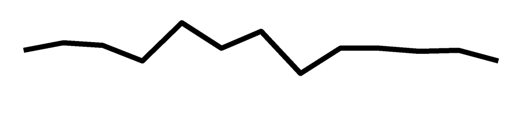

Jonathan Kemp

10

10

NA

NA

11

10

11

7

8

6

8

12

8

0.5333

11

0.6312

0.5341

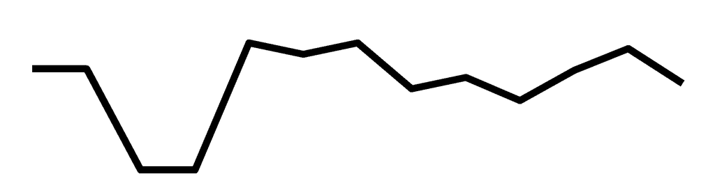

Kieran Place

12

11

8

NA

10

10

9

NA

NA

NA

NA

NA

NA

0.0000

6

0.6742

0.3112

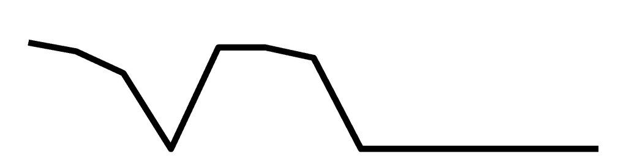

Luca Testa

NA

NA

10

NA

NA

NA

NA

NA

NA

NA

NA

NA

NA

0.0000

1

0.6667

0.0513

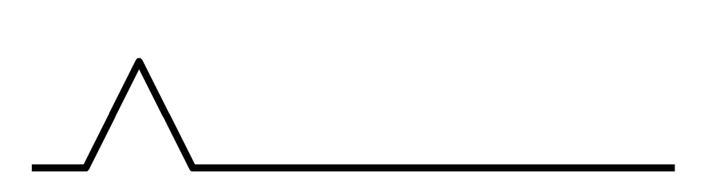

Zakai Bufkin

8

11

7

9

8

10

9

7

9

9

NA

10

NA

0.0000

11

0.5988

0.5067

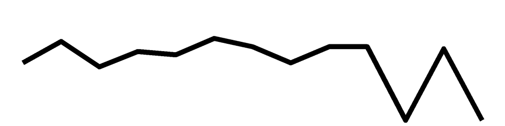

Cameron Patterson

11

9

8

NA

NA

NA

NA

NA

NA

NA

NA

NA

NA

0.0000

3

0.5957

0.1375

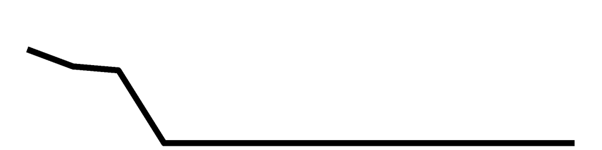

Amadou Bah

9

NA

NA

NA

NA

NA

NA

NA

NA

NA

NA

NA

NA

0.0000

1

0.5625

0.0433

Margaret Williams

9

NA

NA

NA

NA

NA

NA

NA

NA

NA

NA

NA

NA

0.0000

1

0.5625

0.0433

Logan Kauina

9

NA

NA

NA

NA

NA

NA

NA

NA

NA

NA

NA

NA

0.0000

1

0.5625

0.0433

Caleb John

NA

9

NA

NA

NA

NA

NA

NA

NA

NA

NA

NA

NA

0.0000

1

0.5625

0.0433

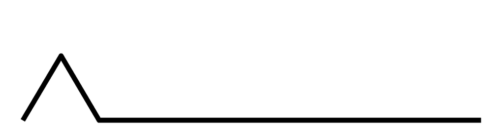

Jay Hajost

11

7

10

NA

6

NA

NA

7

9

NA

NA

NA

NA

0.0000

6

0.5618

0.2593

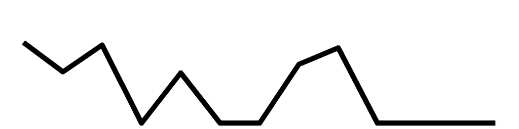

August Rannow

9

NA

NA

NA

7

NA

NA

NA

NA

NA

NA

NA

NA

0.0000

2

0.5333

0.0820

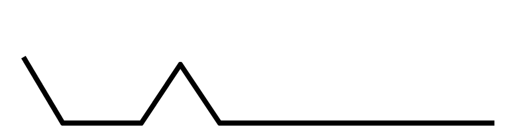

Peter Digenan

9

6

8

10

7

NA

NA

NA

NA

NA

NA

NA

NA

0.0000

5

0.5263

0.2024

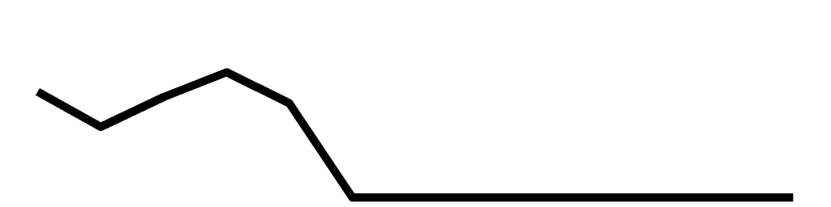

Caleb Doyle

9

NA

NA

NA

NA

NA

NA

6

NA

NA

NA

NA

NA

0.0000

2

0.5000

0.0769

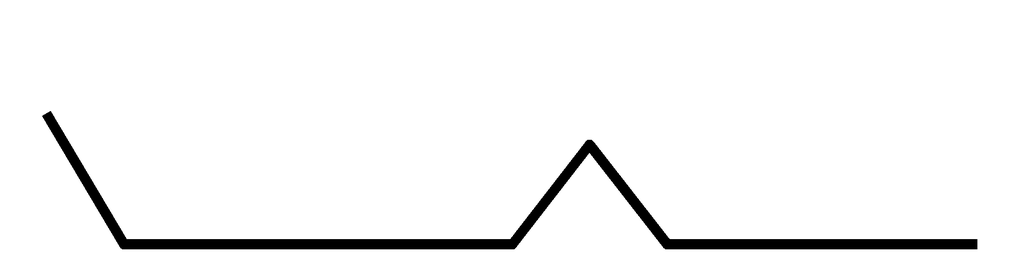

Sydney Johnson

NA

NA

NA

NA

NA

NA

NA

6

NA

NA

NA

NA

NA

0.0000

1

0.4286

0.0330

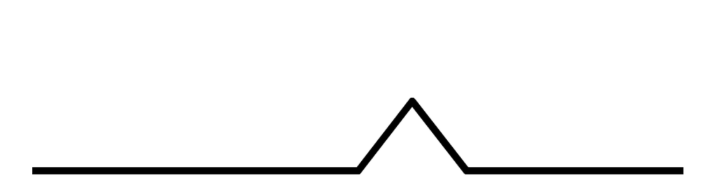

Congrats Caroline Swenson for having the best cadet picks this week, with a correct percentage of 0.8, Congrats Gabriela Peralta for having the best cadet picks this week, with a correct percentage of 0.8, Congrats Ryan Jackovic for having the best cadet picks this week, with a correct percentage of 0.8

| Name | Week 1 | Week 2 | Week 3 | Week 4 | Week 5 | Week 6 | Week 7 | Week 8 | Week 9 | Week 10 | Week 11 | Week 12 | Week 13 | Percent | Weeks Picked | Season Percent | Adj Season Percent | Season Trend |
| --- | --- | --- | --- | --- | --- | --- | --- | --- | --- | --- | --- | --- | --- | --- | --- | --- | --- | --- |
| Caroline Swenson | 8 | 12 | 11 | 13 | 7 | 8 | 10 | NA | 8 | 9 | 8 | NA | 12 | 0.8000 | 11 | 0.6625 | 0.5606 |  |
| Gabriela Peralta | 11 | 8 | 9 | NA | 8 | 8 | 10 | 6 | NA | 8 | 6 | 10 | 12 | 0.8000 | 11 | 0.5963 | 0.5046 |  |
| Ryan Jackovic | 11 | 10 | NA | 7 | 7 | 8 | 8 | 7 | NA | 4 | 5 | NA | 12 | 0.8000 | 10 | 0.5448 | 0.4191 |  |
| Paige Lennon | NA | NA | NA | 11 | 10 | 8 | 11 | 8 | 6 | 8 | 6 | 9 | 11 | 0.7333 | 10 | 0.6154 | 0.4734 |  |
| Sydney Shannon | 10 | 9 | 8 | 9 | 8 | 7 | 9 | 5 | 8 | 10 | 8 | 10 | 11 | 0.7333 | 13 | 0.5895 | 0.5895 |  |
| Laurence Dowd | 10 | 10 | 10 | 9 | 10 | NA | 12 | NA | 10 | 8 | 7 | NA | 10 | 0.6667 | 10 | 0.6575 | 0.5058 |  |
| Victor Olawale-Apanpa | 8 | NA | 10 | NA | 10 | NA | 10 | 7 | 7 | 9 | 6 | 11 | 10 | 0.6667 | 10 | 0.6069 | 0.4668 |  |
| Sidney Cash | 10 | 10 | NA | 10 | NA | 8 | 8 | 7 | 11 | 8 | 5 | 10 | 10 | 0.6667 | 11 | 0.6025 | 0.5098 |  |
| Joshua Gilliard | 9 | 8 | 9 | 10 | 10 | 7 | 10 | 7 | 5 | 8 | NA | 10 | 10 | 0.6667 | 12 | 0.5819 | 0.5371 |  |
| Thomas Bizub | 10 | 14 | 8 | 11 | 8 | 9 | 10 | 8 | 10 | 12 | 9 | 11 | 9 | 0.6000 | 13 | 0.6789 | 0.6789 |  |
| Christopher Erb | 9 | 9 | 7 | 11 | 9 | 11 | 8 | 11 | 10 | 9 | 5 | 10 | 9 | 0.6000 | 13 | 0.6211 | 0.6211 |  |
| Joshua Loyd | 11 | 9 | 8 | NA | 6 | 9 | NA | 6 | 10 | 8 | NA | 10 | 9 | 0.6000 | 10 | 0.5811 | 0.447 |  |
| John White | 10 | 11 | 10 | 8 | 12 | 9 | 11 | 6 | 9 | 9 | 8 | 10 | 8 | 0.5333 | 13 | 0.6368 | 0.6368 |  |
| Jonathan Kemp | 10 | 10 | NA | NA | 11 | 10 | 11 | 7 | 8 | 6 | 8 | 12 | 8 | 0.5333 | 11 | 0.6312 | 0.5341 |  |
| Kieran Place | 12 | 11 | 8 | NA | 10 | 10 | 9 | NA | NA | NA | NA | NA | NA | 0.0000 | 6 | 0.6742 | 0.3112 |  |
| Luca Testa | NA | NA | 10 | NA | NA | NA | NA | NA | NA | NA | NA | NA | NA | 0.0000 | 1 | 0.6667 | 0.0513 |  |
| Zakai Bufkin | 8 | 11 | 7 | 9 | 8 | 10 | 9 | 7 | 9 | 9 | NA | 10 | NA | 0.0000 | 11 | 0.5988 | 0.5067 |  |
| Cameron Patterson | 11 | 9 | 8 | NA | NA | NA | NA | NA | NA | NA | NA | NA | NA | 0.0000 | 3 | 0.5957 | 0.1375 |  |
| Amadou Bah | 9 | NA | NA | NA | NA | NA | NA | NA | NA | NA | NA | NA | NA | 0.0000 | 1 | 0.5625 | 0.0433 |  |
| Margaret Williams | 9 | NA | NA | NA | NA | NA | NA | NA | NA | NA | NA | NA | NA | 0.0000 | 1 | 0.5625 | 0.0433 |  |
| Logan Kauina | 9 | NA | NA | NA | NA | NA | NA | NA | NA | NA | NA | NA | NA | 0.0000 | 1 | 0.5625 | 0.0433 |  |
| Caleb John | NA | 9 | NA | NA | NA | NA | NA | NA | NA | NA | NA | NA | NA | 0.0000 | 1 | 0.5625 | 0.0433 |  |
| Jay Hajost | 11 | 7 | 10 | NA | 6 | NA | NA | 7 | 9 | NA | NA | NA | NA | 0.0000 | 6 | 0.5618 | 0.2593 |  |
| August Rannow | 9 | NA | NA | NA | 7 | NA | NA | NA | NA | NA | NA | NA | NA | 0.0000 | 2 | 0.5333 | 0.082 |  |
| Peter Digenan | 9 | 6 | 8 | 10 | 7 | NA | NA | NA | NA | NA | NA | NA | NA | 0.0000 | 5 | 0.5263 | 0.2024 |  |
| Caleb Doyle | 9 | NA | NA | NA | NA | NA | NA | 6 | NA | NA | NA | NA | NA | 0.0000 | 2 | 0.5 | 0.0769 |  |
| Sydney Johnson | NA | NA | NA | NA | NA | NA | NA | 6 | NA | NA | NA | NA | NA | 0.0000 | 1 | 0.4286 | 0.033 |  |

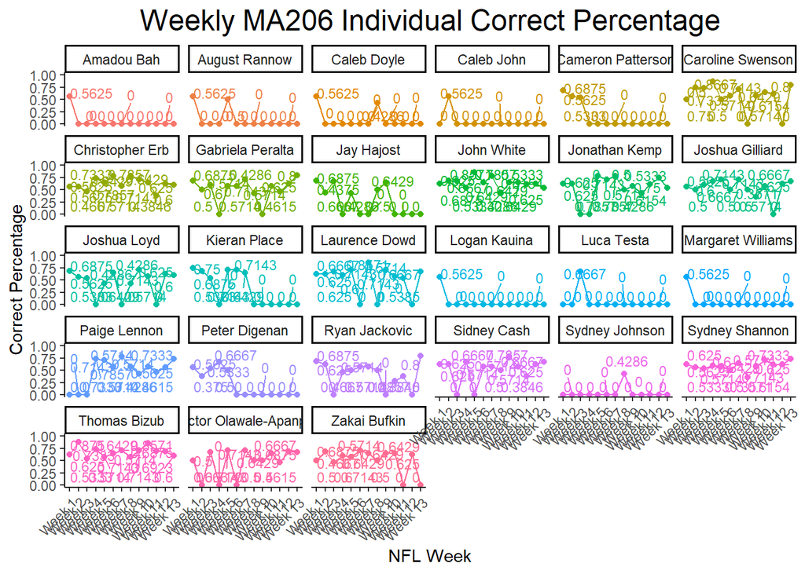

## Combined cadet and instructor prediction

This Week's Combined Cadet and Instructor Predictions

Week 13

| Game | Prediction | Winner | Correct | Correct Votes | Correct Percent |
| --- | --- | --- | --- | --- | --- |
| 1 | Chicago Bears | Detroit Lions | No | 6 | 0.1935 |
| 2 | Tennessee Titans | Cleveland Browns | No | 8 | 0.2581 |
| 3 | Indianapolis Colts | Indianapolis Colts | Yes | 29 | 0.9355 |
| 4 | Minnesota Vikings | Minnesota Vikings | Yes | 31 | 1.0000 |
| 5 | New Orleans Saints | New Orleans Saints | Yes | 27 | 0.8710 |
| 6 | Las Vegas Raiders | Las Vegas Raiders | Yes | 30 | 0.9677 |
| 7 | Miami Dolphins | Miami Dolphins | Yes | 30 | 0.9677 |
| 8 | Seattle Seahawks | New York Giants | No | 0 | 0.0000 |
| 9 | Arizona Cardinals | Los Angeles Rams | No | 15 | 0.4839 |
| 10 | Green Bay Packers | Green Bay Packers | Yes | 28 | 0.9032 |
| 11 | New England Patriots | New England Patriots | Yes | 25 | 0.8065 |
| 12 | Kansas City Chiefs | Kansas City Chiefs | Yes | 31 | 1.0000 |
| 13 | Pittsburgh Steelers | Washington Football Team | No | 0 | 0.0000 |
| 14 | Buffalo Bills | Buffalo Bills | Yes | 28 | 0.9032 |
| 15 | Baltimore Ravens | Baltimore Ravens | Yes | 30 | 0.9677 |

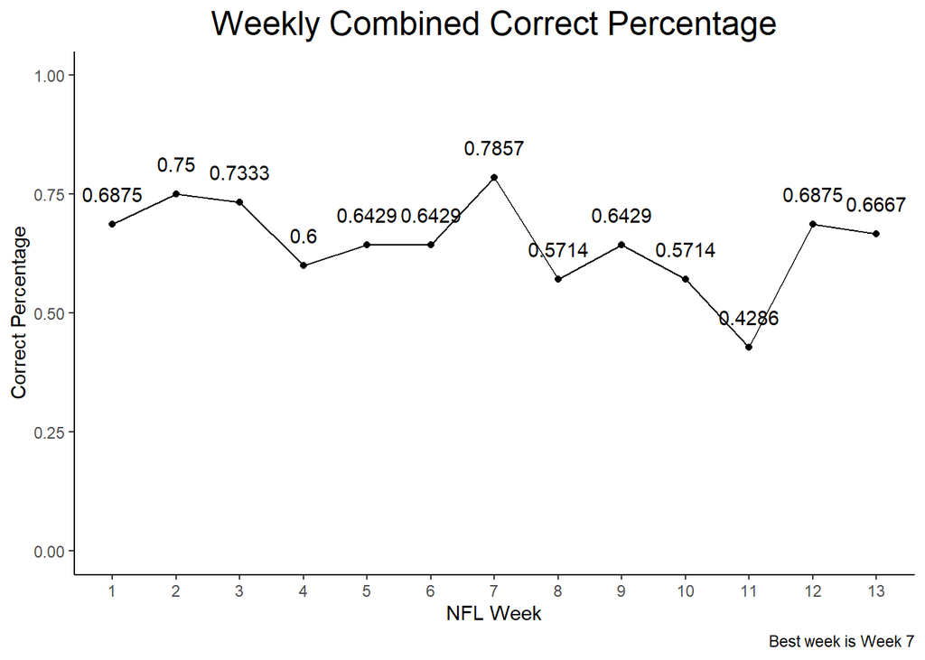

Our combined win percentage for the week is 0.6667

Our season combined win percentage so far is 0.6526

31 total predictions this week

This Week's Matched Cadet and Instructor Predictions

Week 13

| Game | Prediction | Correct |
| --- | --- | --- |
| 1 | Chicago Bears | No |
| 2 | Tennessee Titans | No |
| 3 | Indianapolis Colts | Yes |
| 4 | Minnesota Vikings | Yes |
| 5 | New Orleans Saints | Yes |
| 6 | Las Vegas Raiders | Yes |
| 7 | Miami Dolphins | Yes |
| 8 | Seattle Seahawks | No |
| 9 | -- | -- |
| 10 | Green Bay Packers | Yes |
| 11 | New England Patriots | Yes |
| 12 | Kansas City Chiefs | Yes |
| 13 | Pittsburgh Steelers | No |
| 14 | Buffalo Bills | Yes |
| 15 | Baltimore Ravens | Yes |

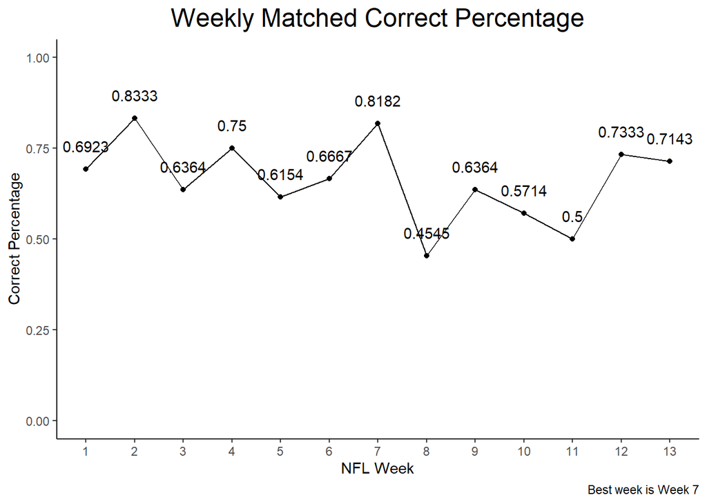

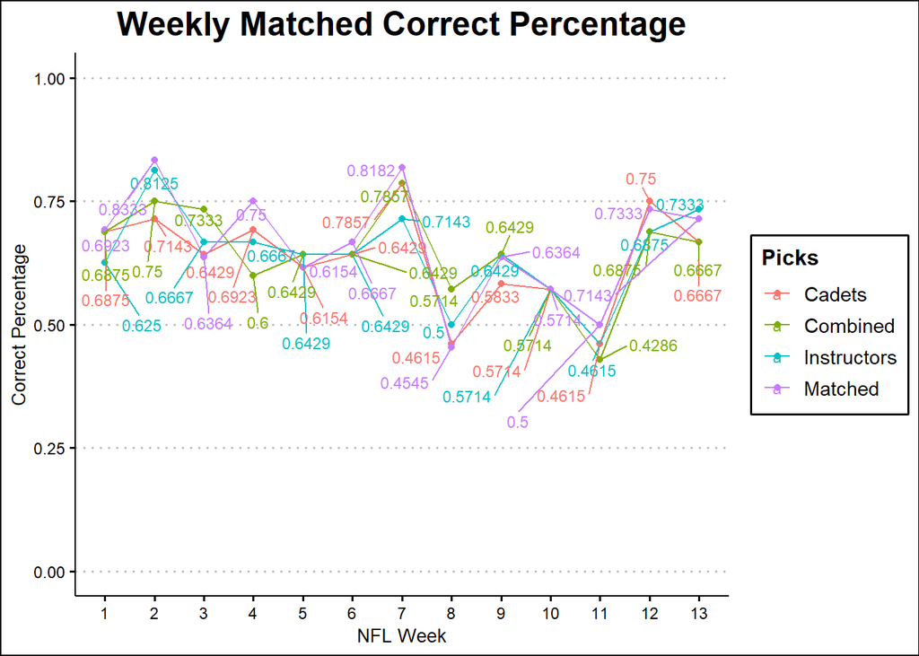